Bootstrap and its applications

# 5.2: Bootstrap

### Part I: motivation example via Weibull distribution

### Part II: Bootstrap in action

Apply the technique in linear models

```r
### (package(boot))
### Load package boot
if(!require('pacman')) {
  install.packages('pacman')
}
pacman::p_load(boot)  # package boot is used.
```

### Part I: A motivating example using Weibull distribution

In real life we only have one data sample. We have nice statistics that can be used to estimate some unknown parameters. But we may not have standard errors handy for the estimates.

Solution: use bootstrap sample to replicate the statistic. The key: bootstrap sample resembles the sample cdf.

#### Weibull distribution: life time to an event:

Ex: how long a product survives; how long a patient survives…

1. Get familiar with Weibull variables

Weibull densities are defined as:

f(x, lambda, k)= (k/lambda) (x/lambda)^(k-1) exp(-(x/lambda)^k) x>0, k>0 (controls the shape of the distribution) and lambda>0 k=1 => exponential disn **Two parameters**: shape=k and scale=lambda Shape parameter controls the degree of skewness.

# Take a look at Weibull shape=.5 and lambda=1

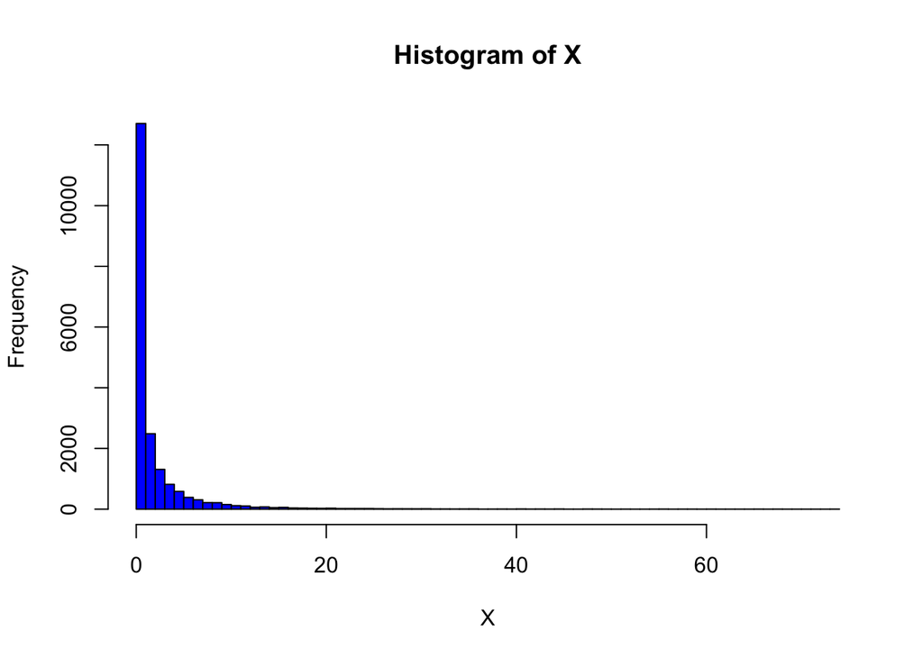

```r
X <- rweibull(20000, shape=.5)  # very skewed to right
hist(X, breaks=100, col="blue") # Note: the sample number n=20000 is large so that we
```

```r
   # get a good look at the Weibull densities.
```

# Four Weibull disn when shape parameters go form .5 to 2

[figure not shown]

```r
par(mfrow=c(4, 1))
shape <- c(.5, 1, 1.5, 2)
for (i in 1:4)
  {hist(rweibull(20000, shape=shape[i]),
        xlab = "",
        breaks = 100,
        col = i,
        main = paste("Weibull dis with shape=", shape[i]))}
```

```r
par(mfrow=c(1,1))
```

# 2) Bootstrap Magic

Let’s study X follows Weibull(shape=1.5 and scale=1) i) A random sample X with n=1000 obs are available to us

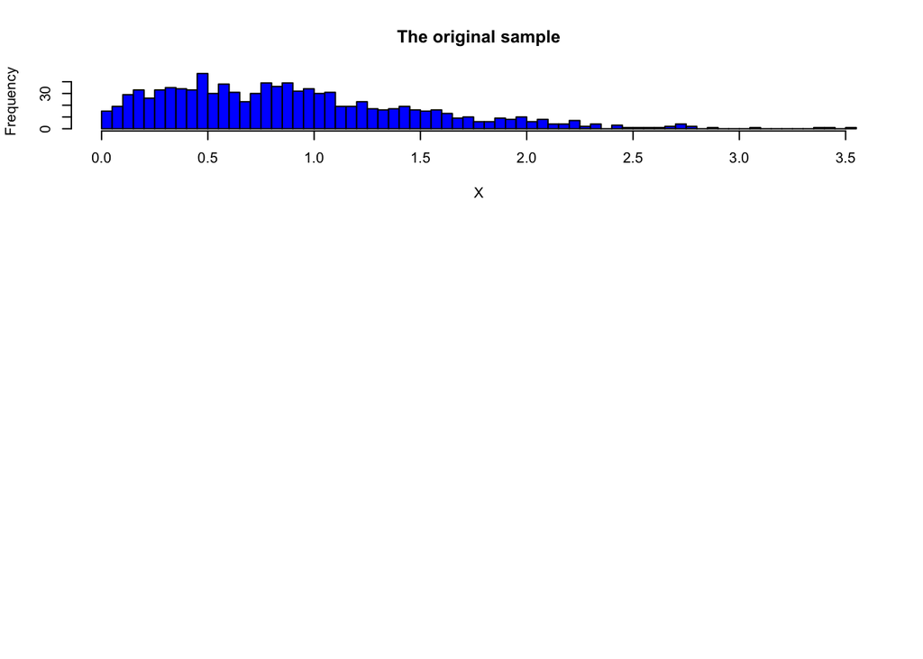

```r
  par(mfrow=c(3,1))
  set.seed(1)
  X <- rweibull(1000, shape=1.5)
  hist(X, breaks=100, col="blue", main="The original sample")
```

2. Now a bootstrap sample: randomly take 1000 obs’n from X with replacement.

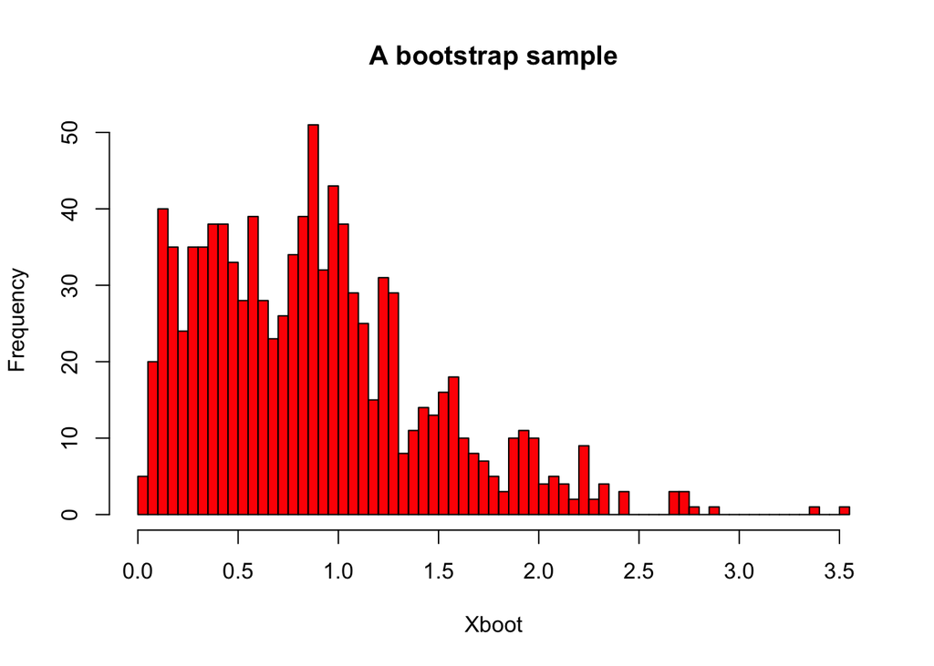

```r
  index <- sample(1000, 1000, replace=TRUE)
  Xboot <- X[index]
  hist(Xboot, breaks=100, col="red", main="A bootstrap sample")
```

```r
  par(mfrow=c(1,1))
```

Can you tell the difference between the two histograms??? Nope

Implication: . We can get another sample from the population for free! . We can then produce any statistics we want for free.

# 3) We now going to estimate theta=E(X^3) (the true third moment is 2) using the sample we have. This relates to Kurtosis.

Step 1: Use sample mean

```r
    theta.hat <- mean(X^3)
    theta.hat
```

```
## [1] 1.891
```

```r
    # but we don't have standard error for theta.hat
```

[output not shown]

Step 3: Construct bootstrap CI of theta=E(X^3), say 95% CI’s.

```
Optional I: use normal CI's
```

```r
          CI.normal <- mean(X^3) + 2* sd(theta.hat.b) *c(-1, 1)
          CI.normal
```

```
## [1] 1.650323 2.131677
```

```r
    # Optional II: Rank theta.hat.b and find the lower .025 and upper .025 percentiles
          CI.quantil <- quantile(theta.hat.b, c(0.025, 0.975));
          CI.quantil
```

```
##     2.5%    97.5%
## 1.675926 2.115158
```

```r
    # The two confidence intervals are very similar.
```

### Exercise for you:Construct a 95% CI for the median of X.

In this case the Bootstrap Percentil ci will work better since the sample median is not exactly unbiased.

### Summary about bootstrap magic

```
 When it works:
     1) The original sample is an iid sample with large n
     2) Bootstrap sample will be a good approx. to a random sample
     3) If we are interested in estimating some unknown parameter say:
         E(X^2), Median(X), Cor(X, Y), beta.i in linear models.
         As long as the estimators we use are unbiased, the bootstrap CI is valid!

 When it doesn't work
     If the pivotal estimate is not a good estimate of the unknown parameters
     The lasso estimates are biased so Bootstrap CI's wont' work.
```

### Part II: Bootstrap in action

When the linear model shows strong heteroscedasticity, all the inference made based on the model assumptions may not be trust worthy. We may try to fix it by transformations on y etc. But we could also do Bootstrap!!!!

Use car data to produce CI’s for some linear coefficients, R^2, etc.

# 1) Get the data

```r
# Set working directory
# rm(list=ls()) # Remove all the existing variables
# dir <- c("/Users/lzhao/Dropbox/STAT471/Data")   # my laptop
# setwd(dir)
```

```r
data1 <- read.csv("car_04_regular.csv")
str(data1)
```

```
## 'data.frame':    226 obs. of  13 variables:
##  $ Make.Model  : Factor w/ 226 levels "Acura_MDX","Acura_NSX",..: 3 5 6 4 2 1 7 8 9 10 ...
##  $ Continent   : Factor w/ 3 levels "Am","As","E": 2 2 2 2 2 2 3 3 3 3 ...
##  $ MPG_City    : int  18 20 23 25 17 17 20 18 17 16 ...
##  $ MPG_Hwy     : int  24 28 32 34 24 23 28 25 24 22 ...
##  $ Horsepower  : int  225 270 200 160 252 265 170 220 330 250 ...
##  $ Weight      : num  3.9 3.58 3.32 2.77 3.2 ...
##  $ Length      : num  197 189 183 172 174 ...
##  $ Width       : num  71.6 72.2 69.4 67.9 71.3 77 76.3 76.1 74.6 76.1 ...
##  $ Seating     : int  5 5 5 4 2 7 5 5 5 5 ...
##  $ Cylinders   : int  6 6 4 4 6 6 4 6 6 6 ...
##  $ Displacement: num  3.5 3.2 2.4 2 3 3.5 1.8 3 4.2 2.7 ...
##  $ Make        : Factor w/ 38 levels "Acura","Audi",..: 1 1 1 1 1 1 2 2 2 2 ...
##  $ Transmission: Factor w/ 3 levels "automatic","cont_variable",..: 1 1 1 1 1 1 1 1 1 1 ...
```

```r
data1$GPM=1/data1$MPG_City  # transform y's
names(data1)
```

```
##  [1] "Make.Model"   "Continent"    "MPG_City"     "MPG_Hwy"
##  [5] "Horsepower"   "Weight"       "Length"       "Width"
##  [9] "Seating"      "Cylinders"    "Displacement" "Make"
## [13] "Transmission" "GPM"
```

```r
data2=data1[, -c(1, 3,4)]
```

# 2) Bootstrap CI’s for coefficients

The following example shows how to produce ci’s for linear coef’s and r-square

```r
library(boot)

fit <- lm(GPM ~ Horsepower+Weight+Length, data2) # let's consider the linear model with three x's
confint(fit)
```

```
##                     2.5 %        97.5 %
## (Intercept)  2.650955e-02  4.371912e-02
## Horsepower   4.371364e-05  6.621438e-05
## Weight       9.467357e-03  1.180915e-02
## Length      -2.310118e-04 -1.150048e-04
```

```r
fit$coef
```

```
##   (Intercept)    Horsepower        Weight        Length
##  3.511434e-02  5.496401e-05  1.063825e-02 -1.730083e-04
```

# Method I: Bootstrap residuals

## Step I: Use original OLS

## Step II: Bootstrap the residuals

## Step III: Update y

## Step IV: Get new OLS estimates and store them

## Step V: Repeat from Step II

## Step VI: Construct bootstrap CI

## Step I: original OLS

```r
fit <- lm(GPM ~ Horsepower+Weight+Length, data2)

N <- nrow(data2)
Nboot <- 1000
b.estimates <- matrix(NA, ncol=length(fit$coefficients), nrow=Nboot) # output of OLS estimates
colnames(b.estimates) <- names(b.estimates)

for(iboot in 1:Nboot) {
  ## Step II: Bootstrap the residuals
  index <- sample(N, replace=T)
  b.residuals <- fit$residuals[index]

  ## Step III: Update y
  b.y <- predict(fit) + b.residuals
  b.data <- data2
  b.data$GPM <- b.y

  ## Step IV: Get new OLS estimates and store them
  b.fit <- lm(GPM ~ Horsepower+Weight+Length, data=b.data)
  b.estimates[iboot,] <- b.fit$coefficients
  if(iboot%%200==0) print(iboot)
}
```

```
## [1] 200
## [1] 400
## [1] 600
## [1] 800
## [1] 1000
```

```r
## Step VI: Construct bootstrap CI
b.se <- apply(b.estimates, 2, sd)
b.CI <- data.frame(cbind(fit$coefficients - 2*b.se, fit$coefficients + 2*b.se))
colnames(b.CI) <- c("lbound (resid. bs)", "ubound (resid. bs)")
b.CI
```

```
##             lbound (resid. bs) ubound (resid. bs)
## (Intercept)       2.650775e-02       4.372092e-02
## Horsepower        4.352053e-05       6.640749e-05
## Weight            9.391066e-03       1.188544e-02
## Length           -2.318194e-04      -1.141973e-04
```

```r
## Compare with the original CI
confint(fit)
```

```
##                     2.5 %        97.5 %
## (Intercept)  2.650955e-02  4.371912e-02
## Horsepower   4.371364e-05  6.621438e-05
## Weight       9.467357e-03  1.180915e-02
## Length      -2.310118e-04 -1.150048e-04
```

# Method II: Pairwise bootstrap

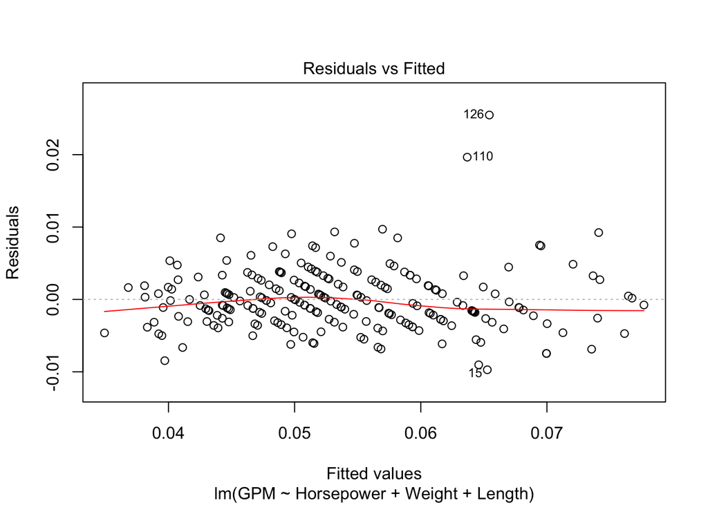

```r
# a quick model diagnoses support the t-intervals and the t/F tests.
# Nevertheless, we can produce bootstrap ci's and compare the two sets.
plot(fit, 1) # residual plot of the fit
```

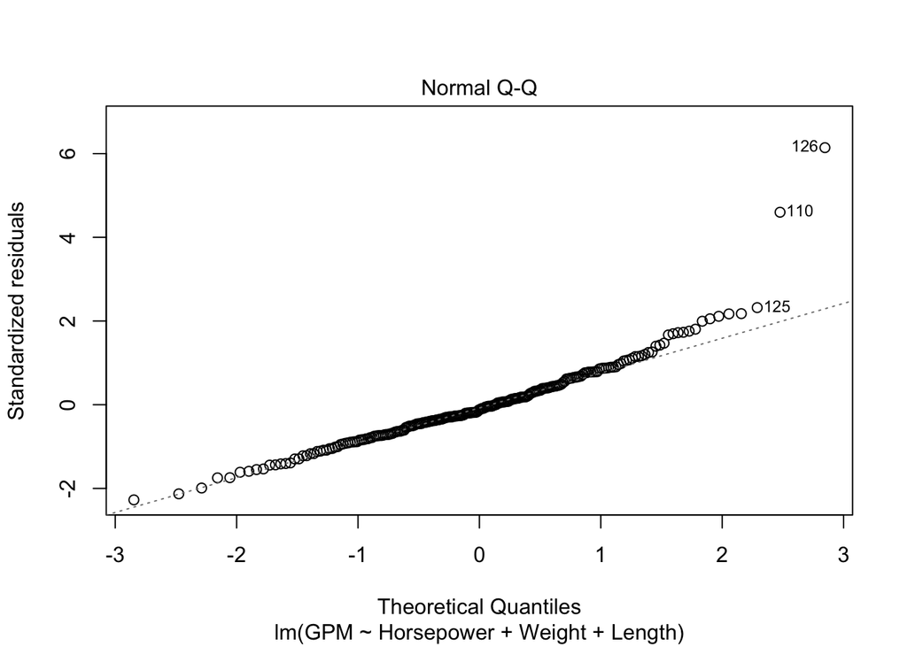

```r
plot(fit, 2) # qq normal of the residuals
```

```r
# first define the function to produce LS est's of beta's
coef <- function(formula, data, indices) {
  data.temp <- data[indices,]
  fit <- lm(formula, data=data.temp)
  return(fit$coef)
}

# Take 100 bootstrap samples and produces b-confidence intervals for each coef's
est.boot <- boot(data=data2, statistic=coef, formula=GPM~Horsepower+Weight+Length, R=100)

# view est.boot
est.boot
```

```
##
## ORDINARY NONPARAMETRIC BOOTSTRAP
##
##
## Call:
## boot(data = data2, statistic = coef, R = 100, formula = GPM ~
##     Horsepower + Weight + Length)
##
##
## Bootstrap Statistics :
##          original        bias     std. error
## t1*  3.511434e-02 -1.270398e-04 4.896349e-03
## t2*  5.496401e-05 -1.845259e-06 1.120219e-05
## t3*  1.063825e-02  4.495497e-05 6.222125e-04
## t4* -1.730083e-04  1.790649e-06 3.296806e-05
```

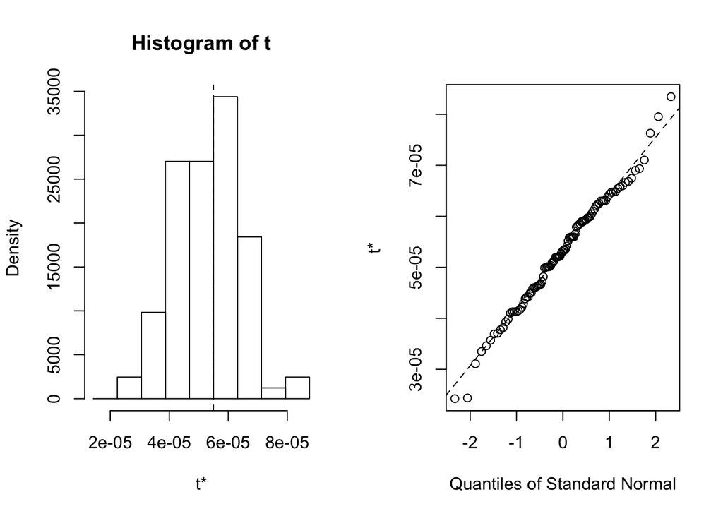

```r
plot(est.boot, index=2) # beta HP
```

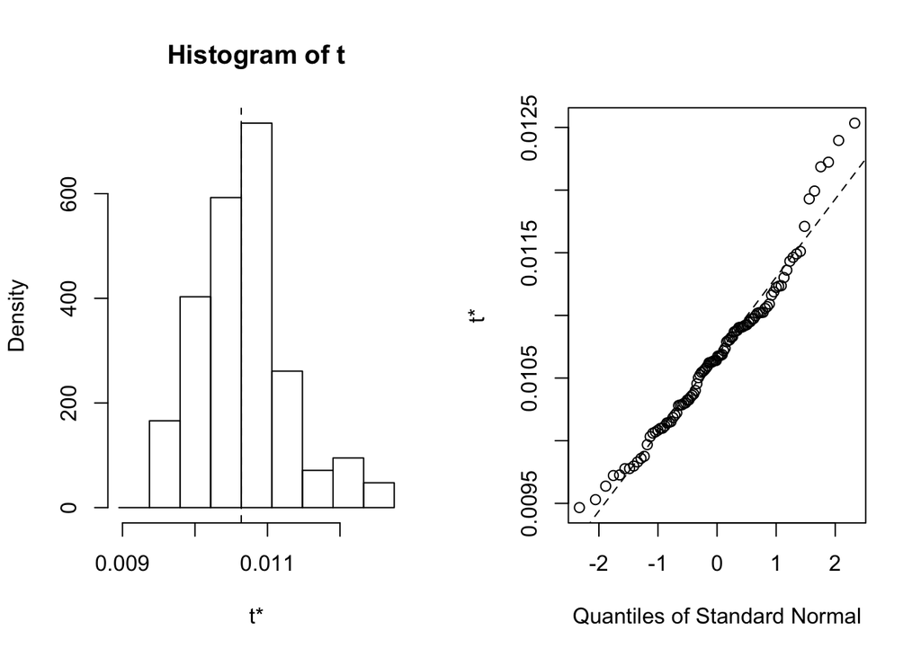

```r
plot(est.boot, index=3) # beta Wt
```

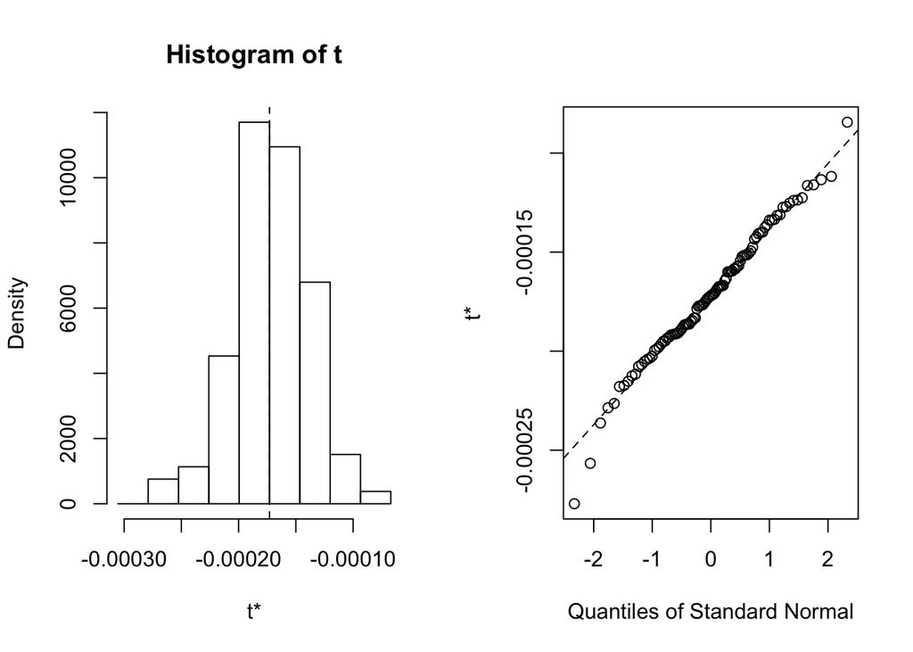

```r
plot(est.boot, index=4) # beta Length
```

```r
boot.ci(est.boot, type="perc", index=2)
```

```
## BOOTSTRAP CONFIDENCE INTERVAL CALCULATIONS
## Based on 100 bootstrap replicates
##
## CALL :
## boot.ci(boot.out = est.boot, type = "perc", index = 2)
##
## Intervals :
## Level     Percentile
## 95%   ( 0.0000,  0.0001 )
## Calculations and Intervals on Original Scale
## Some percentile intervals may be unstable
```

```r
### Get some details
est.b.coef <- data.frame(est.boot$t)
names(est.b.coef) <- c("\beta0", "\beta_HP", "\beta_Wt", "\beta_Length")
fit$coefficients
```

```
##   (Intercept)    Horsepower        Weight        Length
##  3.511434e-02  5.496401e-05  1.063825e-02 -1.730083e-04
```

```r
est.boot$t
```

```
##              [,1]         [,2]        [,3]          [,4]
##   [1,] 0.03352976 4.422787e-05 0.010579426 -1.514539e-04
##   [2,] 0.03704550 5.417151e-05 0.010677027 -1.866945e-04
##   [3,] 0.03155048 4.625079e-05 0.010565302 -1.434662e-04
##   [4,] 0.03555802 4.127514e-05 0.011432198 -1.756811e-04
##   [5,] 0.03214997 5.037421e-05 0.010737573 -1.543372e-04
##   [6,] 0.03828240 5.012099e-05 0.010640701 -1.844990e-04
##   [7,] 0.03192813 4.717924e-05 0.010830985 -1.517597e-04
##   [8,] 0.03278306 6.101467e-05 0.010285670 -1.596717e-04
##   [9,] 0.02614510 5.012576e-05 0.010903025 -1.252436e-04
##  [10,] 0.02966093 4.639739e-05 0.010146910 -1.236688e-04
##  [11,] 0.03596368 6.142213e-05 0.010060466 -1.729183e-04
##  [12,] 0.03383109 5.835107e-05 0.010544956 -1.707755e-04
##  [13,] 0.03655632 5.335566e-05 0.010297400 -1.722632e-04
##  [14,] 0.03367713 6.000326e-05 0.009968355 -1.584603e-04
```

[output cut: 86 more lines]

```r
## pairwise bootstrap CI
b.se.2 <- apply(est.b.coef, 2, sd)
b.CI.2 <- data.frame(cbind(fit$coefficients - 2*b.se.2, fit$coefficients + 2*b.se.2))
colnames(b.CI.2) <- c("lbound (pair bs)", "ubound (pair bs)")
b.CI.2
```

```
##             lbound (pair bs) ubound (pair bs)
## (Intercept)     2.532164e-02     4.490703e-02
## Horsepower      3.255963e-05     7.736839e-05
## Weight          9.393829e-03     1.188268e-02
## Length         -2.389444e-04    -1.070722e-04
```

```r
## Compare with residual bootstrap CI and the original CI
cbind(b.CI, b.CI.2, confint(fit))
```

```
##             lbound (resid. bs) ubound (resid. bs) lbound (pair bs)
## (Intercept)       2.650775e-02       4.372092e-02     2.532164e-02
## Horsepower        4.352053e-05       6.640749e-05     3.255963e-05
## Weight            9.391066e-03       1.188544e-02     9.393829e-03
## Length           -2.318194e-04      -1.141973e-04    -2.389444e-04
##             ubound (pair bs)         2.5 %        97.5 %
## (Intercept)     4.490703e-02  2.650955e-02  4.371912e-02
## Horsepower      7.736839e-05  4.371364e-05  6.621438e-05
## Weight          1.188268e-02  9.467357e-03  1.180915e-02
## Length         -1.070722e-04 -2.310118e-04 -1.150048e-04
```

# 3) Bootstrap CI’s for R^2

```r
# function to obtain R-Square from the data
rsq <- function(formula, data, indices) {
  data.temp <- data[indices,] # allows boot to select sample
  fit <- lm(formula, data=data.temp)
  return(summary(fit)$r.square) # return the r.square
}

# bootstrapping with R replications
b.rsq <- boot(data=data2, statistic=rsq,
              R=100, formula=GPM~Horsepower+Weight+Length)

b.rsq
```

```
##
## ORDINARY NONPARAMETRIC BOOTSTRAP
##
##
## Call:
## boot(data = data2, statistic = rsq, R = 100, formula = GPM ~
##     Horsepower + Weight + Length)
##
##
## Bootstrap Statistics :
##      original      bias    std. error
## t1* 0.8227061 0.005690097  0.02677414
```

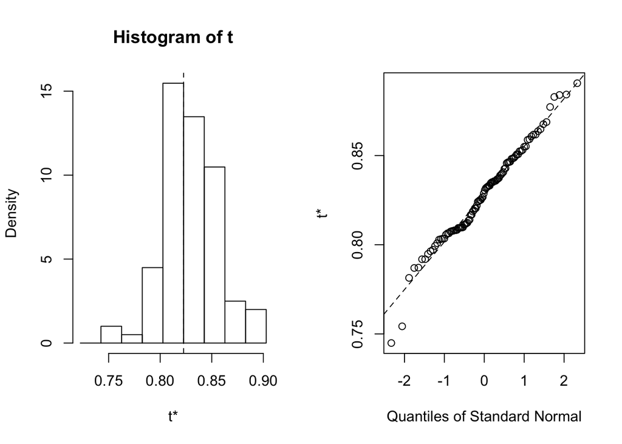

```r
plot(b.rsq)
```

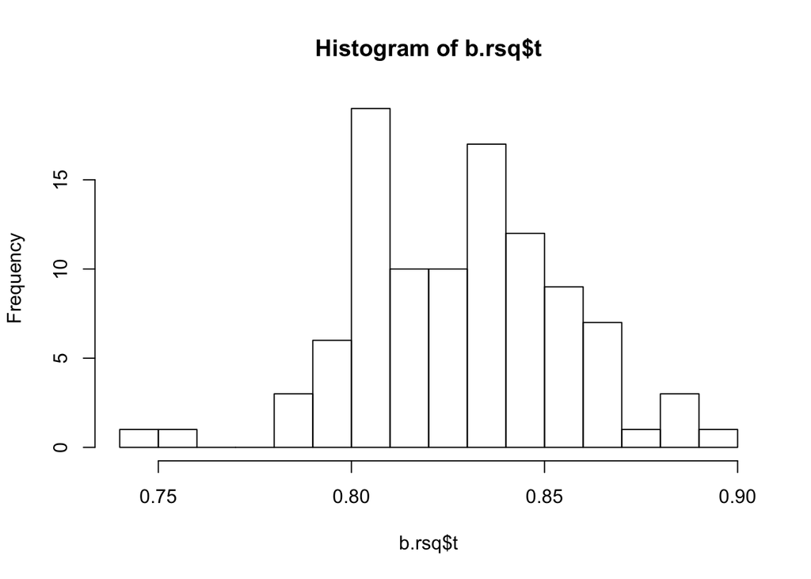

```r
hist(b.rsq$t, breaks=20)
```

```r
boot.ci(b.rsq, type="perc")
```

```
## BOOTSTRAP CONFIDENCE INTERVAL CALCULATIONS
## Based on 100 bootstrap replicates
##
## CALL :
## boot.ci(boot.out = b.rsq, type = "perc")
##
## Intervals :
## Level     Percentile
## 95%   ( 0.7697,  0.8841 )
## Calculations and Intervals on Original Scale
## Some percentile intervals may be unstable
```

```r
boot.ci(b.rsq, type="norm")
```

```
## BOOTSTRAP CONFIDENCE INTERVAL CALCULATIONS
## Based on 100 bootstrap replicates
##
## CALL :
## boot.ci(boot.out = b.rsq, type = "norm")
##
## Intervals :
## Level      Normal
## 95%   ( 0.7645,  0.8695 )
## Calculations and Intervals on Original Scale
```